# Analysis of CRTAC1 levels in blood plasma

Yury V Bukhman

2023-04-07

Project: Johansson CRTAC1 paper 2023  
JIRA Ticket: BIOINFREQ-406. Final version of Johansson CRTAC1 data analysis + methods

## Set-up

1. Set working directory to the location of the R Markdown file
2. Load libraries

```r
library(tidyverse)
```

```r
library(ggplot2)
```

## Load the data

Transform each dataset into one with the following variables:  
1. sample_id 2. patient_condition 3. age 4. log10_CRTAC1_nm

### The hospital patients dataset

Read in the data

```r
data1 <- read_csv("data/deIDed patient metadata and CRTAC1 ELISA for Ron & Yury 110922.csv")
```

Transmute into a tibble that has the columns we need

```r
hospital <- transmute(data1, sample_id = paste("hospital", sample_id, sep="_"), patient_condition = NA, age = Age_less_than_90, log10_CRTAC1_nm = log10(CRTAC1_ELISA_nM))
```

Compute the patient condition column

```r
hospital$patient_condition[data1$COVID == 0 & data1$ICU_1 == 0] = "hospital, no COVID, no ICU"
hospital$patient_condition[data1$COVID == 0 & data1$ICU_1 == 1] = "hospital, no COVID, ICU"
hospital$patient_condition[data1$COVID == 1 & data1$ICU_1 == 0] = "hospital, COVID, no ICU"
hospital$patient_condition[data1$COVID == 1 & data1$ICU_1 == 1] = "hospital, COVID, ICU"
```

Display 3 random rows of data

```r
hospital %>% sample_n(3)
```

| sample_id | patient_condition | age | log10_CRTAC1_nm |
| --- | --- | --- | --- |
| hospital_94 | hospital, COVID, no ICU | 24 | 1.289497 |
| hospital_105 | hospital, no COVID, ICU | 65 | 1.254257 |
| hospital_21 | hospital, COVID, ICU | 66 | 1.110615 |

### The long COVID dataset

Read in the data table and the two metadata tables

```r
data2_crtac1 <- read_csv("data/CRTAC1 ELISA H and LC updated 121922.csv")
data2_meta1 <- read_csv("data/C NC PC T and LC 08172022 For Mats.csv")
data2_meta2 <- read_csv("data/01042022 New LC Patient Data for Mats.csv")
```

Join the data and the metadata columns that we need

```r
data2_1 <- merge(data2_crtac1, select(data2_meta1, Sample, Age, Pulmonary_dis), by.x = "subject", by.y = "Sample") %>% rename(COPD = Pulmonary_dis)
data2_2 <- merge(data2_crtac1, select(data2_meta2, Sample, Age), by.x = "subject", by.y = "Sample") %>% mutate(COPD = "N")
long_covid <- rbind(data2_1, data2_2)
```

Transmute into a tibble that has the columns we need

```r
long_covid <- transmute(long_covid, sample_id = subject, patient_condition = NA, age = Age, COPD = COPD, log10_CRTAC1_nm = log10(CRTAC1_ELISA_nM))
```

Calculate the patient_condition variable

```r
long_covid$patient_condition[grep("H",long_covid$sample_id)] <- "healthy"
long_covid$patient_condition[grep("LC",long_covid$sample_id)] <- "long COVID"
long_covid$patient_condition[grepl("LC",long_covid$sample_id) & long_covid$COPD == "Y"] <- "long COVID + COPD"
```

Drop the COPD column

```r
long_covid <- long_covid %>% select(-COPD)
```

Display 3 random rows of data

```r
long_covid %>% sample_n(3)
```

| sample_id | patient_condition | age | log10_CRTAC1_nm |
| --- | --- | --- | --- |
| LC1075 | long COVID | 56 | 1.729649 |
| H14 | healthy | 50 | 1.481857 |
| H4 | healthy | 54 | 1.704134 |

### The COPD dataset

Read in the data

```r
copd_crtac <- read_csv("data/COPD patients.csv")
copd_ages <- read_csv("data/COPD Ages.csv")
```

Join CRTAC1 data to the metadata

```r
copd <- merge(copd_crtac, copd_ages, by.x = "Patient_No", by.y = "COPD_ID")
```

Transmute COPD data into a tibble with the columns that we need

```r
copd <- transmute(copd, sample_id = paste("copd", Patient_No, sep = "_"), patient_condition = "COPD", age = Age, log10_CRTAC1_nm = log10(CRTAC1_ELISA_nM))
```

Display 3 random rows of data

```r
copd %>% sample_n(3)
```

| sample_id | patient_condition | age | log10_CRTAC1_nm |
| --- | --- | --- | --- |
| copd_17 | COPD | 65 | 1.555436 |
| copd_22 | COPD | 64 | 1.523495 |
| copd_31 | COPD | 72 | 1.261497 |

### Concatenate the 3 datasets

```r
crtac1 <- rbind(hospital,long_covid,copd)
crtac1 %>% sample_n(3)
```

| sample_id | patient_condition | age | log10_CRTAC1_nm |
| --- | --- | --- | --- |
| H17 | healthy | 42 | 1.5612926 |
| hospital_53 | hospital, COVID, no ICU | 35 | 0.8385236 |
| hospital_56 | hospital, COVID, no ICU | 33 | 0.4847496 |

Transform patient_condition into a factor and summarize the dataset

```r
crtac1$patient_condition <- factor(crtac1$patient_condition, levels = c("healthy", "COPD", "long COVID", "long COVID + COPD", "hospital, no COVID, no ICU", "hospital, no COVID, ICU", "hospital, COVID, no ICU", "hospital, COVID, ICU"))
summary(crtac1)
```

```
##   sample_id                       patient_condition      age
##  Length:330         long COVID             :111     Min.   :19.00
##  Class :character   COPD                   : 55     1st Qu.:48.00
##  Mode  :character   hospital, COVID, no ICU: 51     Median :57.50
##                     hospital, COVID, ICU   : 51     Mean   :56.82
##                     healthy                : 20     3rd Qu.:66.75
##                     long COVID + COPD      : 16     Max.   :89.00
##                     (Other)                : 26
##  log10_CRTAC1_nm
##  Min.   :-0.2141
##  1st Qu.: 1.0434
##  Median : 1.2842
##  Mean   : 1.2376
##  3rd Qu.: 1.5137
##  Max.   : 2.0882
##
```

## Exploratory data analysis

Mean age and CRTAC1 level in each patient condition, ordered by the mean CRTAC1 level, descending.

```r
crtac1 %>%
  group_by(patient_condition) %>%
  summarise(mean_age = mean(age),
             mean_crtac1 = mean(log10_CRTAC1_nm)) %>%
  arrange(desc(mean_crtac1))
```

| patient_condition | mean_age | mean_crtac1 |
| --- | --- | --- |
| healthy | 48.20000 | 1.522319 |
| hospital, no COVID, no ICU | 60.30000 | 1.484842 |
| long COVID + COPD | 52.87500 | 1.456365 |
| long COVID | 49.55856 | 1.408625 |
| COPD | 64.20000 | 1.337395 |
| hospital, no COVID, ICU | 66.00000 | 1.215231 |
| hospital, COVID, no ICU | 59.68627 | 1.034625 |
| hospital, COVID, ICU | 62.86275 | 0.738927 |

Define “normal range” as mean +- 3 sd of the healthy controls. Compute upper and lower bounds of this range.

```r
norm_mean <- crtac1 %>% filter(patient_condition == "healthy") %>% summarise(mean(log10_CRTAC1_nm)) %>% unlist()
norm_sd <- crtac1 %>% filter(patient_condition == "healthy") %>% summarise(sd(log10_CRTAC1_nm)) %>% unlist()
norm_low <- norm_mean - 3*norm_sd
norm_high <- norm_mean + 3*norm_sd
```

Plot CRTAC1 level vs. age for each patient condition, marking the normal mean and range as dashed horizontal lines

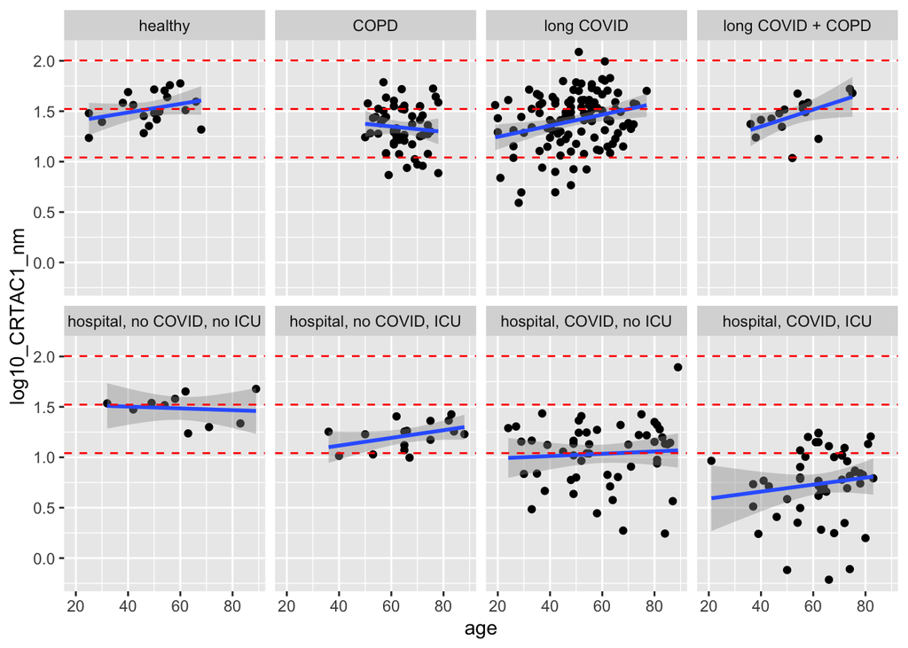

```r
ggplot(crtac1, aes(x = age, y = log10_CRTAC1_nm)) +
  geom_point() + geom_smooth(method = "lm") +
  geom_hline(yintercept = norm_mean, col = "red", lty = 2) +
  geom_hline(yintercept = norm_low, col = "red", lty = 2) +
  geom_hline(yintercept = norm_high, col = "red", lty = 2) +
  facet_wrap(~ patient_condition, nrow = 2)
```

## A linear model accounting for patient condition and age

```r
lm1 <- lm(log10_CRTAC1_nm ~ patient_condition + age, data = crtac1)
summary(lm1)
```

```
##
## Call:
## lm(formula = log10_CRTAC1_nm ~ patient_condition + age, data = crtac1)
##
## Residuals:
##      Min       1Q   Median       3Q      Max
## -0.96291 -0.13866  0.03221  0.18767  0.76559
##
## Coefficients:
##                                              Estimate Std. Error t value
## (Intercept)                                  1.369690   0.080369  17.043
## patient_conditionCOPD                       -0.235589   0.072657  -3.242
## patient_conditionlong COVID                 -0.117996   0.065594  -1.799
## patient_conditionlong COVID + COPD          -0.080758   0.090692  -0.890
## patient_conditionhospital, no COVID, no ICU -0.075793   0.105399  -0.719
## patient_conditionhospital, no COVID, ICU    -0.363453   0.092642  -3.923
## patient_conditionhospital, COVID, no ICU    -0.524067   0.072337  -7.245
## patient_conditionhospital, COVID, ICU       -0.829823   0.073030 -11.363
## age                                          0.003167   0.001101   2.877
##                                             Pr(>|t|)
## (Intercept)                                  < 2e-16 ***
## patient_conditionCOPD                       0.001310 **
## patient_conditionlong COVID                 0.072977 .
## patient_conditionlong COVID + COPD          0.373885
## patient_conditionhospital, no COVID, no ICU 0.472601
## patient_conditionhospital, no COVID, ICU    0.000107 ***
## patient_conditionhospital, COVID, no ICU    3.24e-12 ***
## patient_conditionhospital, COVID, ICU        < 2e-16 ***
## age                                         0.004290 **
## ---
## Signif. codes:  0 '***' 0.001 '**' 0.01 '*' 0.05 '.' 0.1 ' ' 1
##
## Residual standard error: 0.27 on 321 degrees of freedom
## Multiple R-squared:  0.4868, Adjusted R-squared:  0.474
## F-statistic: 38.06 on 8 and 321 DF,  p-value: < 2.2e-16
```

The negative effects of COPD, acute form of COVID, and ICU on CRTAC1 levels are all statistically significant, with the COVID+ICU being the strongest. The long COVID term is borderline-significant, with p value of 0.07. There is also a statistically significant positive effect of the patient’s age. Age patient condition explain about half of all the variance in this dataset.

### Diagnostic plots

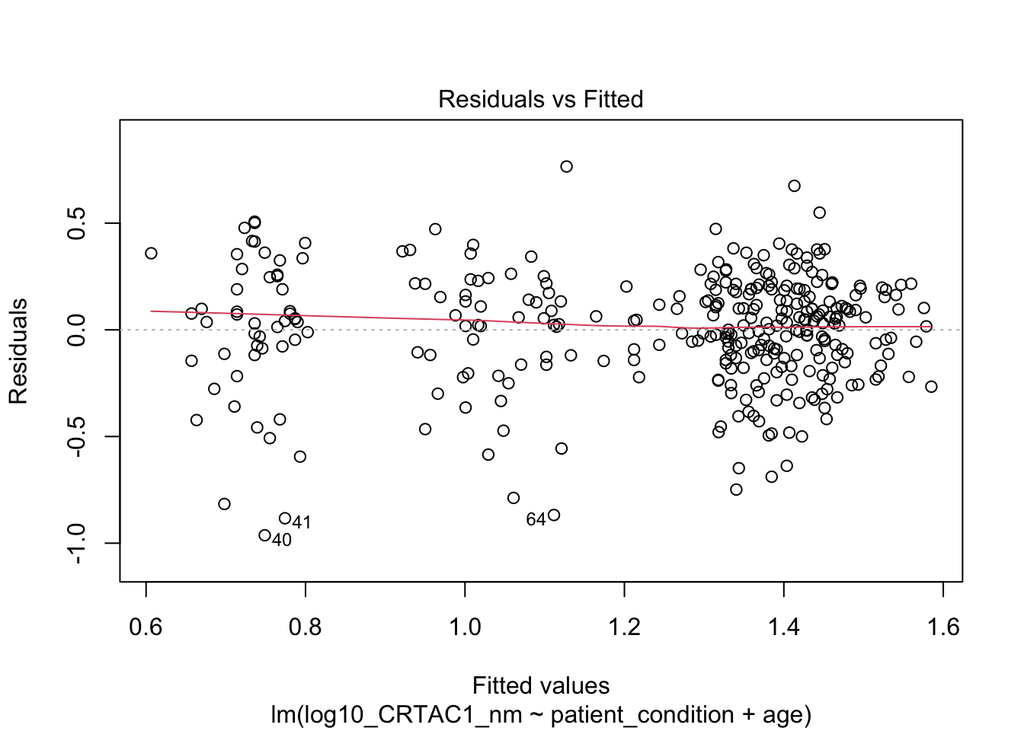

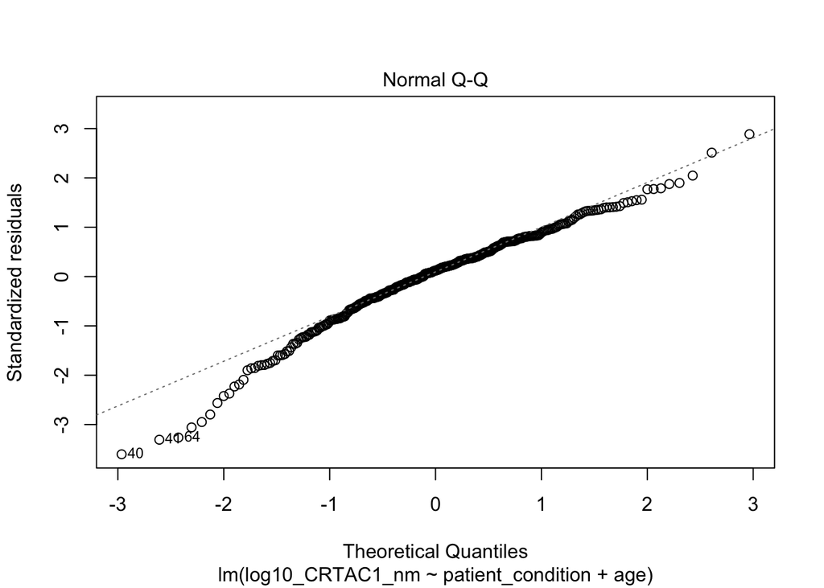

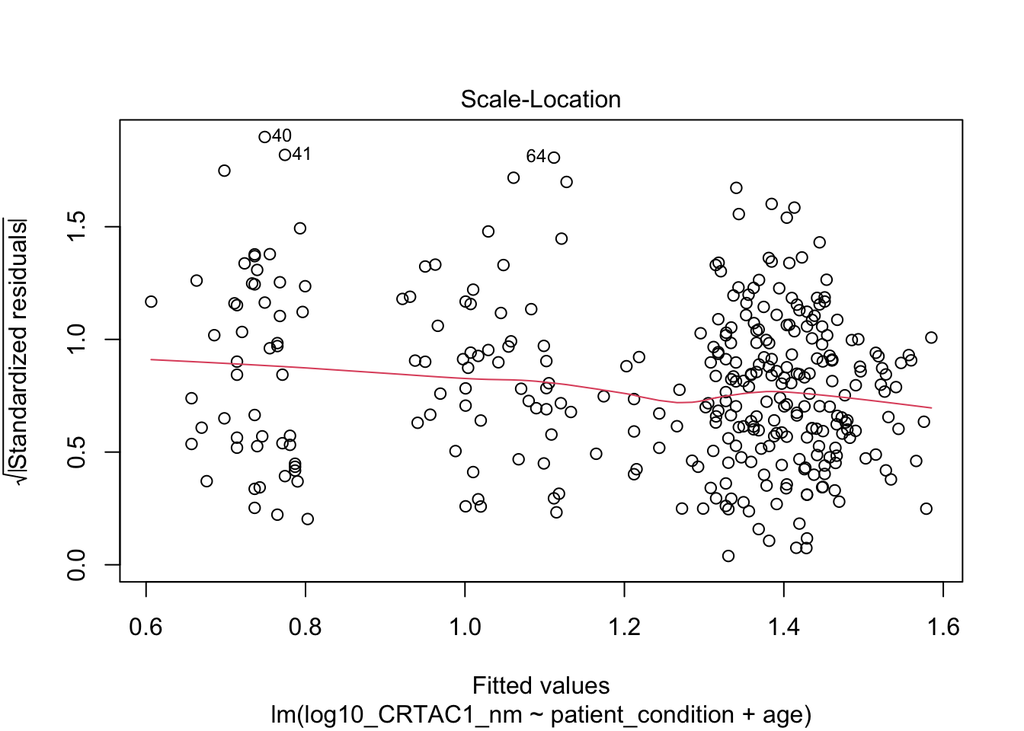

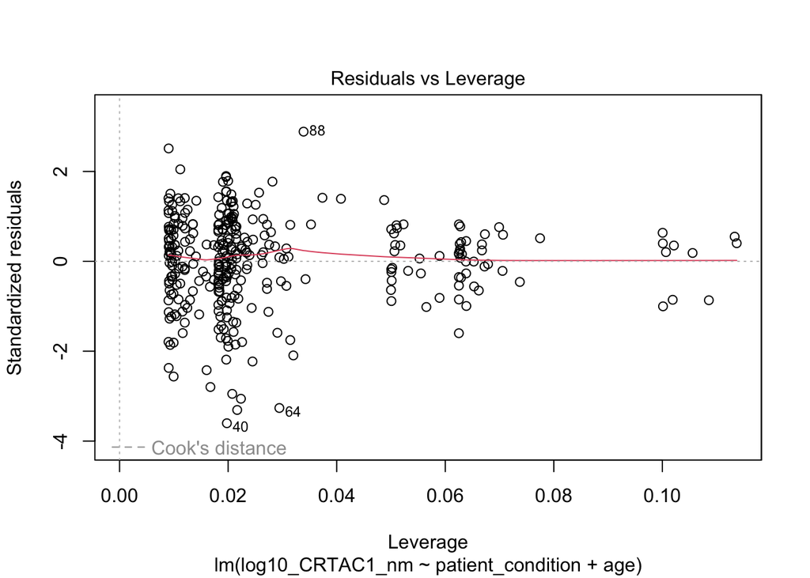

```r
plot(lm1)
```

There is a slight deviation from normality, with higher values tending to have lower variance. However, this is not bad enough to cause a major concern. Additionally, there are no high-leverage outliers in the data.

## Explore contrasts

Compute estimated marginal means (EMMs)

```r
library(emmeans)
emms = emmeans(lm1, "patient_condition")
emms
```

```
##  patient_condition          emmean     SE  df lower.CL upper.CL
##  healthy                      1.55 0.0611 321    1.429    1.670
##  COPD                         1.31 0.0373 321    1.241    1.387
##  long COVID                   1.43 0.0268 321    1.379    1.484
##  long COVID + COPD            1.47 0.0676 321    1.336    1.602
##  hospital, no COVID, no ICU   1.47 0.0855 321    1.306    1.642
##  hospital, no COVID, ICU      1.19 0.0682 321    1.052    1.320
##  hospital, COVID, no ICU      1.03 0.0379 321    0.951    1.100
##  hospital, COVID, ICU         0.72 0.0384 321    0.644    0.795
##
## Confidence level used: 0.95
```

Plot EMMS of each patient condition at the average age of 56.8

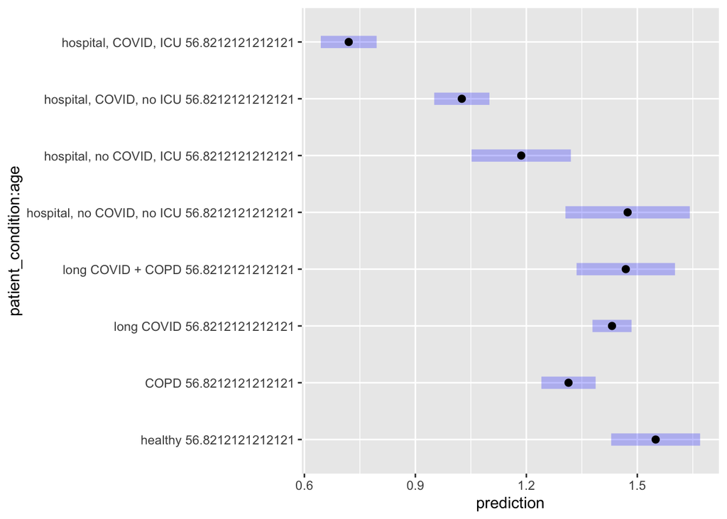

```r
plot(ref_grid(lm1))
```

Interaction plot of the EMMs

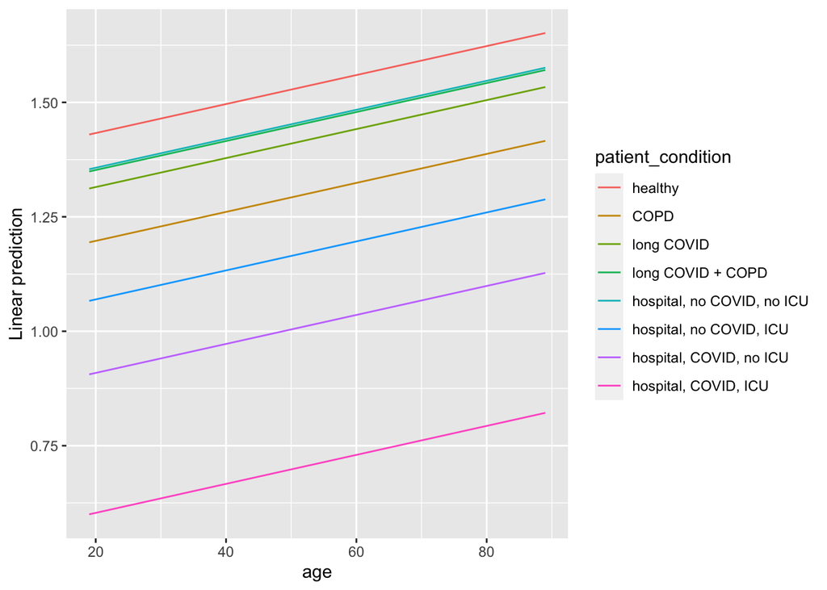

```r
emmip(ref_grid(lm1, cov.reduce = FALSE), patient_condition ~ age)
```

Statistical significance of certain contrasts

```r
Contrasts = list(COPD_vs_Healthy                = c(-1,  1, 0, 0, 0, 0, 0, 0),
                 Long_COVID_vs_Healthy          = c(-1,  0, 1, 0, 0, 0, 0, 0),
                 Long_COVID_and_COPD_vs_Healthy = c(-1,  0, 0, 1, 0, 0, 0, 0)
                 )
contrast(emms, Contrasts, adjust="sidak")
```

```
##  contrast                       estimate     SE  df t.ratio p.value
##  COPD_vs_Healthy                 -0.2356 0.0727 321  -3.242  0.0039
##  Long_COVID_vs_Healthy           -0.1180 0.0656 321  -1.799  0.2033
##  Long_COVID_and_COPD_vs_Healthy  -0.0808 0.0907 321  -0.890  0.7546
##
## P value adjustment: sidak method for 3 tests
```

## A subset of long COVID patients have abnormally low levels of CRTAC1

Although the mean CRTAC1 level in long COVID patients may not be significantly different from healthy controls under the normal distribution assumption, the distribution in this group deviates from normality and there is a subset of patients with abnormally low CRTAC1 levels

Violin plots of the CRTAC1 distributions show that the mode of the long COVID data is nearly identical to that of the healthy controls. However, the former is skewed, with long lower tail.

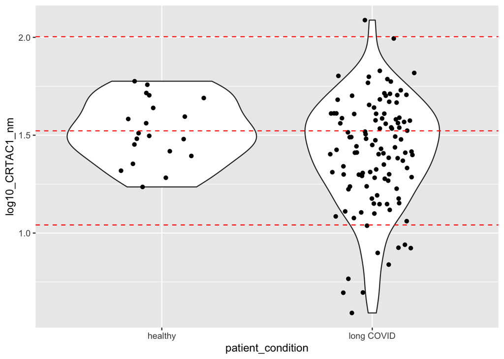

```r
ggplot(filter(crtac1, patient_condition %in% c("healthy", "long COVID")), aes(x = patient_condition, y = log10_CRTAC1_nm)) + geom_violin() + geom_jitter(width = 0.2) +
  geom_hline(yintercept = norm_mean, col = "red", lty = 2) +
  geom_hline(yintercept = norm_low, col = "red", lty = 2) +
  geom_hline(yintercept = norm_high, col = "red", lty = 2)
```

A normal QQ plot also indicates that the CTRAC1 distribution in long COVID patients is skewed.

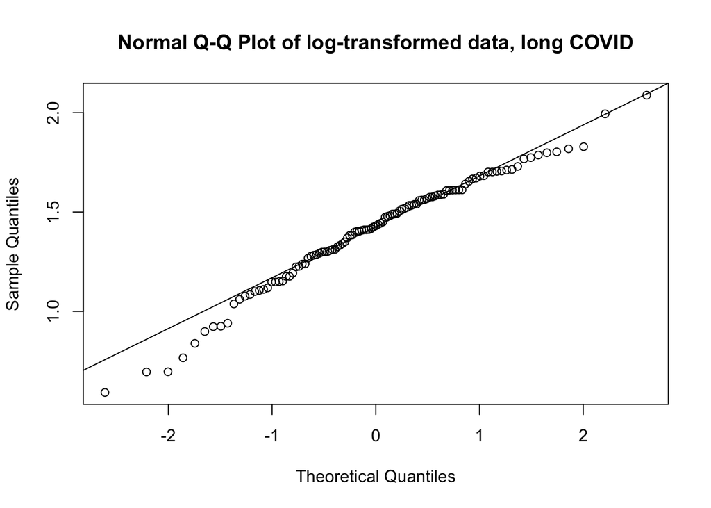

```r
qqnorm((filter(crtac1, patient_condition == "long COVID")$log10_CRTAC1_nm),
       main = "Normal Q-Q Plot of log-transformed data, long COVID")
qqline(filter(crtac1, patient_condition == "long COVID")$log10_CRTAC1_nm)
```

The Shapiro-Wilk test also indicates that the CRTAC1 distribution in long COVID patients significantly deviates from the normal

```r
crtac1 %>% group_by(patient_condition) %>% summarise(Shapiro_Wilk_pval = shapiro.test(log10_CRTAC1_nm)$p.value)
```

| patient_condition | Shapiro_Wilk_pval |
| --- | --- |
| healthy | 0.730478937 |
| COPD | 0.592478016 |
| long COVID | 0.048434509 |
| long COVID + COPD | 0.668718878 |
| hospital, no COVID, no ICU | 0.445420642 |
| hospital, no COVID, ICU | 0.311034089 |
| hospital, COVID, no ICU | 0.054957855 |
| hospital, COVID, ICU | 0.005611004 |

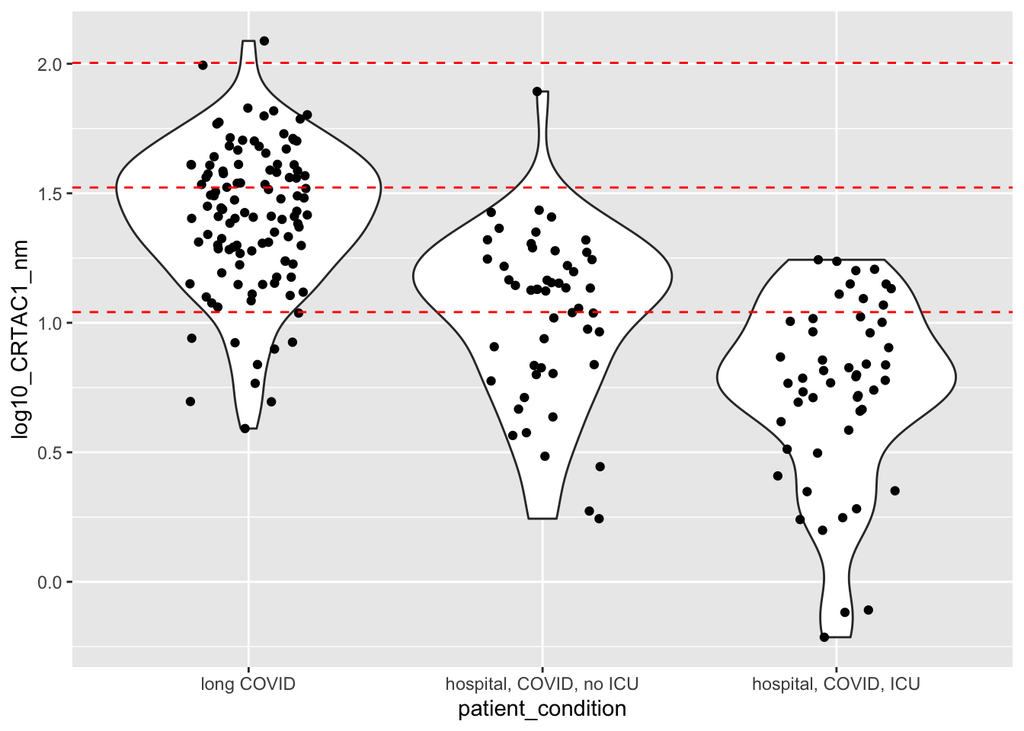

```r
ggplot(filter(crtac1, patient_condition %in% c("long COVID","hospital, COVID, no ICU","hospital, COVID, ICU")), aes(x = patient_condition, y = log10_CRTAC1_nm)) + geom_violin() + geom_jitter(width = 0.2) +
  geom_hline(yintercept = norm_mean, col = "red", lty = 2) +
  geom_hline(yintercept = norm_low, col = "red", lty = 2) +
  geom_hline(yintercept = norm_high, col = "red", lty = 2)
```

The long COVID + COPD group is at least somewhat skewed as well. The most likely reason that it doesn’t appear statistically significant by the Shapiro-Wilk test is that it has only 16 patients. In contrast, the non-COVID groups are much less skewed, if at all. Here are the violin plots of all patient groups in the dataset.

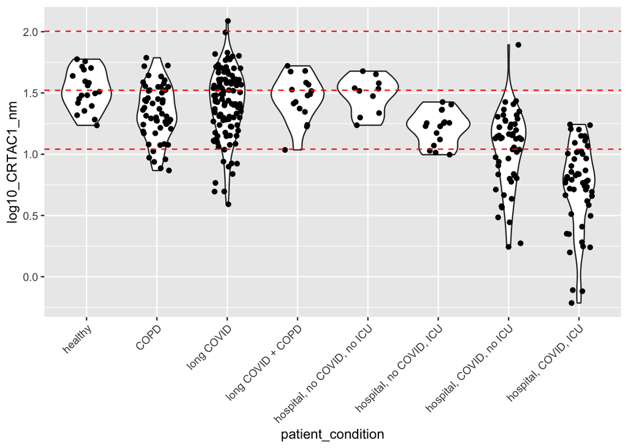

```r
ggplot(crtac1, aes(x = patient_condition, y = log10_CRTAC1_nm)) + geom_violin() + geom_jitter(width = 0.2) +
  geom_hline(yintercept = norm_mean, col = "red", lty = 2) +
  geom_hline(yintercept = norm_low, col = "red", lty = 2) +
  geom_hline(yintercept = norm_high, col = "red", lty = 2) +
  theme(axis.text.x = element_text(angle = 45, hjust = 1))
```

[output not shown]